# R for Marketing Research and Analytics

Chris Chapman and Elea McDonnell Feit  
February 2016

**Chapter 9: Advanced Linear Modeling Topics**

Website for all data files:  
http://r-marketing.r-forge.r-project.org/data.html

### Topics

We cover several separate topics that extending discussion of linear models.

- Collinearity: detecting and fixing
- Logistic regression
- Hierarchical linear models (mixed effects models)
- Bayesian estimation of hierarchical linear models

## Collinearity

### First load the data

We will use the retail transaction + CRM-like data from Chapter 4:

```r
cust.df <- read.csv("http://goo.gl/PmPkaG")
summary(cust.df)
```

```
    cust.id            age         credit.score   email
 Min.   :   1.0   Min.   :19.34   Min.   :543.0   no :186
 1st Qu.: 250.8   1st Qu.:31.43   1st Qu.:691.7   yes:814
 Median : 500.5   Median :35.10   Median :725.5
 Mean   : 500.5   Mean   :34.92   Mean   :725.5
 3rd Qu.: 750.2   3rd Qu.:38.20   3rd Qu.:757.2
 Max.   :1000.0   Max.   :51.86   Max.   :880.8

 distance.to.store  online.visits     online.trans      online.spend
 Min.   :  0.2136   Min.   :  0.00   Min.   :  0.000   Min.   :   0.00
 1st Qu.:  3.3383   1st Qu.:  0.00   1st Qu.:  0.000   1st Qu.:   0.00
 Median :  7.1317   Median :  6.00   Median :  2.000   Median :  37.03
 Mean   : 14.6553   Mean   : 28.29   Mean   :  8.385   Mean   : 170.32
 3rd Qu.: 16.6589   3rd Qu.: 31.00   3rd Qu.:  9.000   3rd Qu.: 177.89
 Max.   :267.0864   Max.   :606.00   Max.   :169.000   Max.   :3593.03

  store.trans      store.spend      sat.service   sat.selection
 Min.   : 0.000   Min.   :  0.00   Min.   :1.00   Min.   :1.000
 1st Qu.: 0.000   1st Qu.:  0.00   1st Qu.:3.00   1st Qu.:2.000
 Median : 1.000   Median : 30.05   Median :3.00   Median :2.000
 Mean   : 1.323   Mean   : 47.58   Mean   :3.07   Mean   :2.401
 3rd Qu.: 2.000   3rd Qu.: 66.49   3rd Qu.:4.00   3rd Qu.:3.000
 Max.   :12.000   Max.   :705.66   Max.   :5.00   Max.   :5.000
                                   NA's   :341    NA's   :341
```

### Initial linear model

Suppose we want to estimate online spend on the basis of other variables. A first attempt might be:

```r
spend.m1 <- lm(online.spend ~ .,
               data=subset(cust.df[ , -1], online.spend > 0))
summary(spend.m1)
```

```
Call:
lm(formula = online.spend ~ ., data = subset(cust.df[, -1], online.spend >
    0))

Residuals:
     Min       1Q   Median       3Q      Max
-234.097   -8.828    0.519    9.956  227.238

Coefficients:
                   Estimate Std. Error t value Pr(>|t|)
(Intercept)        6.718948  33.537665   0.200   0.8413
age                0.422773   0.450825   0.938   0.3489
credit.score      -0.033698   0.043977  -0.766   0.4440
emailyes          -5.689283   5.806621  -0.980   0.3278
distance.to.store -0.043548   0.100539  -0.433   0.6651
online.visits     -0.072269   0.204061  -0.354   0.7234
online.trans      20.610744   0.667450  30.880   <2e-16 ***
store.trans        0.135018   3.211943   0.042   0.9665
store.spend        0.001796   0.078732   0.023   0.9818
sat.service        5.638769   3.016181   1.870   0.0623 .
sat.selection     -4.370606   2.909073  -1.502   0.1338
---
Signif. codes:  0 '***' 0.001 '**' 0.01 '*' 0.05 '.' 0.1 ' ' 1

Residual standard error: 42.77 on 407 degrees of freedom
  (214 observations deleted due to missingness)
Multiple R-squared:  0.9831,    Adjusted R-squared:  0.9827
F-statistic:  2363 on 10 and 407 DF,  p-value: < 2.2e-16
```

### Puzzle

Online spend is highly related to online transactions … but not to online *visits*?

```r
                   Estimate Std. Error t value Pr(>|t|)
(Intercept)        6.718948  33.537665   0.200   0.8413
online.visits     -0.072269   0.204061  -0.354   0.7234
online.trans      20.610744   0.667450  30.880   <2e-16 ***
store.trans        0.135018   3.211943   0.042   0.9665
store.spend        0.001796   0.078732   0.023   0.9818
sat.service        5.638769   3.016181   1.870   0.0623 .
```

That doesn't make sense. If they visit more, they should spend more.

What's going on?

### Something we omitted

Before modeling, look at the data! Scatter plots show problems here. Many items are skewed and also highly correlated.

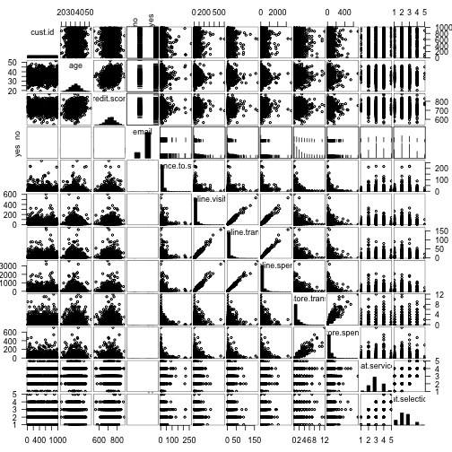

```r
library(gpairs)
gpairs(cust.df)
```

### Fixing skew

We could fix skew — e.g., in transactions and visits – one variable at a time. Or, we can automate it.

```r
autoTransform <- function(x) {
  library(forecast)
  return(scale(BoxCox(x, BoxCox.lambda(x))))
}

cust.df.bc <- cust.df[complete.cases(cust.df), -1]  # copy of data
cust.df.bc <- subset(cust.df.bc, online.spend > 0)  # data with spend
numcols <- which(colnames(cust.df.bc) != "email")   # numeric columns
cust.df.bc[, numcols] <- lapply(cust.df.bc[, numcols], autoTransform)
```

We use the Box-Cox transformation to transform data to approximate normality, using `BoxCox` from the `forecast` package.

Data is also rescaled with `scale` to be on Z-score (standardized) scale.

### Plot again

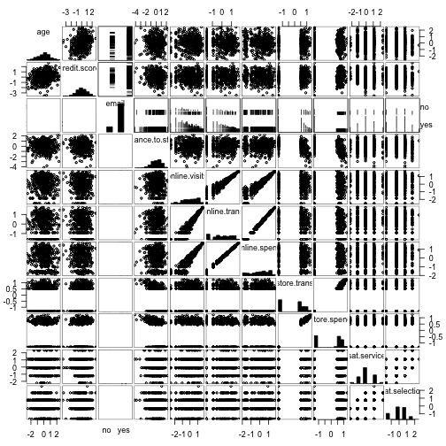

```r
gpairs(cust.df.bc)
```

### Does that solve it?

It's a good thing to do, but not enough.

```r
spend.m2 <- lm(online.spend ~ ., data=cust.df.bc)
summary(spend.m2)
```

```
Call:
lm(formula = online.spend ~ ., data = cust.df.bc)

Residuals:
     Min       1Q   Median       3Q      Max
-0.38976 -0.05409  0.00027  0.05591  0.26628

Coefficients:
                    Estimate Std. Error t value Pr(>|t|)
(Intercept)       -0.0059639  0.0108943  -0.547    0.584
age                0.0001875  0.0044821   0.042    0.967
credit.score      -0.0026632  0.0045185  -0.589    0.556
emailyes           0.0071023  0.0119316   0.595    0.552
distance.to.store -0.0020362  0.0048800  -0.417    0.677
online.visits     -0.0003913  0.0126165  -0.031    0.975
online.trans       0.9960378  0.0126687  78.622   <2e-16 ***
store.trans       -0.0266674  0.0480675  -0.555    0.579
store.spend        0.0274099  0.0475888   0.576    0.565
sat.service        0.0059429  0.0052732   1.127    0.260
sat.selection      0.0030628  0.0052624   0.582    0.561
---
Signif. codes:  0 '***' 0.001 '**' 0.01 '*' 0.05 '.' 0.1 ' ' 1

Residual standard error: 0.08747 on 407 degrees of freedom
Multiple R-squared:  0.9925,    Adjusted R-squared:  0.9923
F-statistic:  5410 on 10 and 407 DF,  p-value: < 2.2e-16
```

### Check variables in the model

For any linear model with correlated variables check the *variable inflation factor*.

VIF measures how much a variable's standard error is inflated due to its variance being shared with other variables.

```r
library(car)
vif(spend.m2)
```

```
              age      credit.score             email distance.to.store
         1.094949          1.112784          1.046874          1.297978
    online.visits      online.trans       store.trans       store.spend
         8.675817          8.747756        125.931383        123.435407
      sat.service     sat.selection
         1.515576          1.509377
```

Rule of thumb: VIF > 5 indicates a problem. In this case, the `..visits` and `..trans` variables are problematic.

### Solution 1: Omit covariates

Fit the model again, omitting one each of the `visits` and `trans` variables.

```r
spend.m4 <- lm(online.spend ~ . -online.trans -store.trans,
               data=cust.df.bc)
vif(spend.m4)
```

```
              age      credit.score             email distance.to.store
         1.081411          1.103586          1.033945          1.211607
    online.visits       store.spend       sat.service     sat.selection
         1.026148          1.215208          1.507866          1.509001
```

### Solution 1: Omit variables (result)

Now visits are related to spend (!)

```r
summary(spend.m4)
```

```
Call:
lm(formula = online.spend ~ . - online.trans - store.trans, data = cust.df.bc)

Residuals:
     Min       1Q   Median       3Q      Max
-1.36373 -0.13135  0.05888  0.18476  1.03794

Coefficients:
                    Estimate Std. Error t value Pr(>|t|)
(Intercept)       -0.0923395  0.0435047  -2.123   0.0344 *
age               -0.0333779  0.0178813  -1.867   0.0627 .
credit.score      -0.0084524  0.0180637  -0.468   0.6401
emailyes           0.1099655  0.0476011   2.310   0.0214 *
distance.to.store  0.0001702  0.0189271   0.009   0.9928
online.visits      0.9295374  0.0174184  53.365   <2e-16 ***
store.spend        0.0092463  0.0189552   0.488   0.6260
sat.service       -0.0121405  0.0211147  -0.575   0.5656
sat.selection      0.0048591  0.0211226   0.230   0.8182
---
Signif. codes:  0 '***' 0.001 '**' 0.01 '*' 0.05 '.' 0.1 ' ' 1

Residual standard error: 0.3511 on 409 degrees of freedom
Multiple R-squared:  0.8791,    Adjusted R-squared:  0.8767
F-statistic: 371.6 on 8 and 409 DF,  p-value: < 2.2e-16
```

### Solution 2: Reduce Dimensions

Because `visits` and `trans` are very closely related, we could regard them as a single dimension (“activity”) that happens to be measured twice.

We can reduce that to a single dimension using PCA.

```r
pc.online <- prcomp(cust.df.bc[ , c("online.visits", "online.trans")])
cust.df.bc$online <- pc.online$x[ , 1]

pc.store <- prcomp(cust.df.bc[ , c("store.trans", "store.spend")])
cust.df.bc$store <- pc.store$x[ , 1]
```

### Solution 2: Model

Now we use the principal component as the predictor.

```r
spend.m5 <- lm(online.spend ~ email + age + credit.score +
                 distance.to.store + sat.service + sat.selection +
                 online + store,
               data=cust.df.bc)

vif(spend.m5)
```

```
            email               age      credit.score distance.to.store
         1.039458          1.081430          1.103206          1.224019
      sat.service     sat.selection            online             store
         1.508487          1.509001          1.032362          1.228073
```

### Solution 2: Result

```r
summary(spend.m5)
```

```
Call:
lm(formula = online.spend ~ email + age + credit.score + distance.to.store +
    sat.service + sat.selection + online + store, data = cust.df.bc)

Residuals:
     Min       1Q   Median       3Q      Max
-0.83697 -0.08532  0.01288  0.09664  0.73327

Coefficients:
                    Estimate Std. Error  t value Pr(>|t|)
(Intercept)       -3.928e-02  2.410e-02   -1.630   0.1039
emailyes           4.678e-02  2.638e-02    1.773   0.0769 .
age               -1.695e-02  9.882e-03   -1.715   0.0871 .
credit.score      -3.649e-03  9.981e-03   -0.366   0.7148
distance.to.store -2.666e-05  1.051e-02   -0.003   0.9980
sat.service       -2.762e-03  1.167e-02   -0.237   0.8130
sat.selection      3.153e-03  1.167e-02    0.270   0.7872
online            -7.019e-01  6.933e-03 -101.247   <2e-16 ***
store             -2.712e-03  7.455e-03   -0.364   0.7162
---
Signif. codes:  0 '***' 0.001 '**' 0.01 '*' 0.05 '.' 0.1 ' ' 1

Residual standard error: 0.1941 on 409 degrees of freedom
Multiple R-squared:  0.9631,    Adjusted R-squared:  0.9623
F-statistic:  1333 on 8 and 409 DF,  p-value: < 2.2e-16
```

## Logistic Regression

### Logistic Regression: Intro

Logistic regression predicts a binary outcome from any mix of predictors. See book Section 9.2.1 for more background and intuition.

First, we'll set up some data. This reflects whether a *season pass* was sold for a ski area, as a function of *sales channel* and *bundle promotion*.

```r
pass.df <- read.csv("http://goo.gl/J8MH6A")
pass.df$Promo <- factor(pass.df$Promo, levels=c("NoBundle", "Bundle"))
summary(pass.df)
```

```
  Channel          Promo           Pass
 Email: 633   NoBundle:1482   NoPass :1567
 Mail :1328   Bundle  :1674   YesPass:1589
 Park :1195
```

Note: we set the `bundle` factor levels explicitly (why?)

### Logistic regression with glm(): model 1

Is `Promotion` related to `Pass` purchase? (Warning: naive model!)

```r
pass.m1 <- glm(Pass ~ Promo, data=pass.df, family=binomial)
summary(pass.m1)
```

```
Call:
glm(formula = Pass ~ Promo, family = binomial, data = pass.df)

Deviance Residuals:
   Min      1Q  Median      3Q     Max
-1.262  -1.097   1.095   1.095   1.260

Coefficients:
            Estimate Std. Error z value Pr(>|z|)
(Intercept) -0.19222    0.05219  -3.683 0.000231 ***
PromoBundle  0.38879    0.07167   5.425 5.81e-08 ***
---
Signif. codes:  0 '***' 0.001 '**' 0.01 '*' 0.05 '.' 0.1 ' ' 1

(Dispersion parameter for binomial family taken to be 1)

    Null deviance: 4375.0  on 3155  degrees of freedom
Residual deviance: 4345.4  on 3154  degrees of freedom
AIC: 4349.4

Number of Fisher Scoring iterations: 3
```

### Effect of promotion: take 1

```r
coef(pass.m1)
```

```
(Intercept) PromoBundle
 -0.1922226   0.3887910
```

```r
exp(coef(pass.m1))                    # odds ratio
```

```
(Intercept) PromoBundle
  0.8251232   1.4751962
```

```r
plogis(0.3888) / (1-plogis(0.3888))   # another way to look at it ...
```

```
[1] 1.475209
```

```r
exp(confint(pass.m1))                 # conf interval
```

```
               2.5 %    97.5 %
(Intercept) 0.744749 0.9138654
PromoBundle 1.282055 1.6979776
```

### Remember: Visualize first!

We see that `bundle` has lower proportional sales of `pass` after it is broken out by `channel`. This is a case of *Simpson's paradox*.

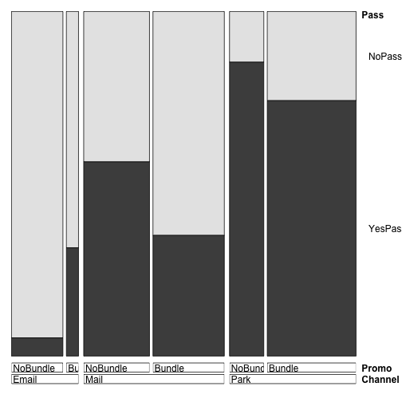

```r
library(vcd)    # install if needed
doubledecker(table(pass.df))
```

### New Model with Channel and interaction

The more complete model suggests that `bundle` has an effect only in *email*. We would want to avoid bundling in other channels (park, direct mail).

```r
pass.m3 <- glm(Pass ~ Promo + Channel + Promo:Channel,
               data=pass.df, family=binomial)
exp(confint(pass.m3))   # CI for odds ratios
```

```
                              2.5 %       97.5 %
(Intercept)              0.03688720   0.08032263
PromoBundle              4.78970184  14.31465957
ChannelMail             15.54800270  35.97860059
ChannelPark             64.74364028 173.57861021
PromoBundle:ChannelMail  0.02795867   0.09102369
PromoBundle:ChannelPark  0.03135437   0.11360965
```

If the data were real, follow-up research would be good to understand why this is occurring.

### Bonus: Visualize Effects

We can compare the effect of the different interventions (channel, bundle).

First, get the coefs and CIs:

```r
pass.ci <- data.frame(confint(pass.m3))     # confidence intervals
pass.ci$X50 <- coef(pass.m3)                # midpoint estimate
pass.ci$Factor <- rownames(pass.ci)         # for ggplot2 labels
pass.ci
```

```
                           X2.5..   X97.5..       X50
(Intercept)             -3.299891 -2.521704 -2.888312
PromoBundle              1.566468  2.661284  2.107058
ChannelMail              2.743932  3.582924  3.144013
ChannelPark              4.170435  5.156631  4.645466
PromoBundle:ChannelMail -3.577028 -2.396636 -2.980844
PromoBundle:ChannelPark -3.462402 -2.174987 -2.811479
                                         Factor
(Intercept)                         (Intercept)
PromoBundle                         PromoBundle
ChannelMail                         ChannelMail
ChannelPark                         ChannelPark
PromoBundle:ChannelMail PromoBundle:ChannelMail
PromoBundle:ChannelPark PromoBundle:ChannelPark
```

### Build a ggplot, 1

First we add data for the midpoint, upper, and lower CIs:

```r
library(ggplot2)
p <- ggplot(pass.ci[-1, ],
            aes(x=Factor, y=exp(X50),
                ymax=exp(X97.5..), ymin=exp(X2.5..)))
```

We take the `exp()` of each one to get the odds ratio.

Next add midpoints and error bars:

```r
p <- p + geom_point(size=4) + geom_errorbar(width=0.25)
```

And add a line where odds ratio==1.0 (no effect):

```r
p <- p + geom_hline(yintercept=1, linetype="dotted",
                    size=1.5, color="red")
```

### Build a ggplot, 2

Now plot that with titles (and rotate it for simplicity):

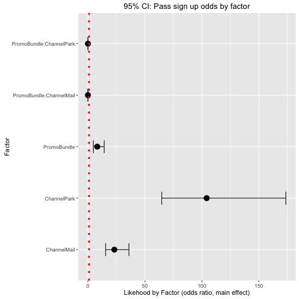

```r
p + ylab("Likehood by Factor (odds ratio, main effect)") +
  ggtitle(paste("95% CI: Pass sign up odds by factor")) +
  coord_flip()
```

## Hierarchical Linear Models

### Ratings-based Conjoint Analysis data

The data represent *preference* on a 10 point scale for roller coasters, based on the features of the coasters.

```r
conjoint.df <- read.csv("http://goo.gl/G8knGV")
conjoint.df$speed  <- factor(conjoint.df$speed)   # why?
conjoint.df$height <- factor(conjoint.df$height)  # why?
summary(conjoint.df)
```

```
    resp.id           rating       speed     height       const
 Min.   :  1.00   Min.   : 1.000   40: 800   200:1400   Steel:1400
 1st Qu.: 50.75   1st Qu.: 3.000   50:1200   300:1200   Wood :1800
 Median :100.50   Median : 5.000   60: 800   400: 600
 Mean   :100.50   Mean   : 5.268   70: 400
 3rd Qu.:150.25   3rd Qu.: 7.000
 Max.   :200.00   Max.   :10.000
    theme
 Dragon:1600
 Eagle :1600
```

### Aggregate model

A simple model is just overall `rating ~ features`:

```r
ride.lm <- lm(rating ~ speed + height + const + theme, data=conjoint.df)
summary(ride.lm)
```

```
Call:
lm(formula = rating ~ speed + height + const + theme, data = conjoint.df)

Residuals:
    Min      1Q  Median      3Q     Max
-5.8394 -1.3412 -0.0186  1.2798  6.9269

Coefficients:
            Estimate Std. Error t value Pr(>|t|)
(Intercept)  3.07307    0.08102  37.932  < 2e-16 ***
speed50      0.82077    0.10922   7.515 7.35e-14 ***
speed60      1.57443    0.12774  12.326  < 2e-16 ***
speed70      4.48697    0.15087  29.740  < 2e-16 ***
height300    2.94551    0.09077  32.452  < 2e-16 ***
height400    1.44738    0.12759  11.344  < 2e-16 ***
constWood   -0.11826    0.11191  -1.057    0.291
themeEagle  -0.75454    0.11186  -6.745 1.81e-11 ***
---
Signif. codes:  0 '***' 0.001 '**' 0.01 '*' 0.05 '.' 0.1 ' ' 1

Residual standard error: 1.967 on 3192 degrees of freedom
Multiple R-squared:  0.5039,    Adjusted R-squared:  0.5029
F-statistic: 463.2 on 7 and 3192 DF,  p-value: < 2.2e-16
```

### Hierarchical model

However, individuals probably vary in their preference. As marketers we can use that information for both strategy — maximizing appeal across our lineup — and for targeting.

A hierarchical model has these elements:

- Overall coefficients for the sample
- Individual deviations from those estimates
- Variance measures (e.g., variance of the deviations)

We could allow individuals to vary by:

- Overall preference, or intercept (scale anchor point per respondent)
- Preference per feature (feature preference estimates per respondent)

### HLM model 1: intercept

We tell R to estimate intercepts per respondent using `1 | resp.id`. This requires an HLM package such as `lme4`.

`1` is formula syntax for *intercept*, and we add `| resp.id` to estimate that for each unique set of observations grouped by `resp.id`:

```r
library(lme4)
ride.hlm1 <- lmer(rating ~ speed + height + const + theme +
                    (1 | resp.id), data=conjoint.df)
```

### HLM model 1: result (overall)

Overall CIs for the fixed (full sample) estimates:

```r
confint(ride.hlm1)
```

```
                 2.5 %      97.5 %
.sig01       0.4863012  0.67647225
.sigma       1.8316382  1.92672254
(Intercept)  2.9015492  3.24459566
speed50      0.6163380  1.02520548
speed60      1.3353275  1.81352404
speed70      4.2045696  4.76937338
height300    2.7756113  3.11540557
height400    1.2085632  1.68620634
constWood   -0.3277217  0.09121113
themeEagle  -0.9639303 -0.54515530
```

### HLM model 1: result (individual)

We get individual deviations from the sample coefficients using `ranef()`. Total coefficients per individual are obtained with `coef()`:

```r
head(ranef(ride.hlm1)$resp.id, 4)
```

```
  (Intercept)
1 -0.65085636
2 -0.04821158
3 -0.31186867
4 -0.12354218
```

```r
head(coef(ride.hlm1)$resp.id, 4)
```

```
  (Intercept)   speed50  speed60  speed70 height300 height400  constWood
1    2.422216 0.8207718 1.574426 4.486971  2.945508  1.447385 -0.1182553
2    3.024861 0.8207718 1.574426 4.486971  2.945508  1.447385 -0.1182553
3    2.761204 0.8207718 1.574426 4.486971  2.945508  1.447385 -0.1182553
4    2.949530 0.8207718 1.574426 4.486971  2.945508  1.447385 -0.1182553
  themeEagle
1 -0.7545428
2 -0.7545428
3 -0.7545428
4 -0.7545428
```

### HLM model 2: slope + intercept

It's unlikely that respondents differ only on the intercept. We can add `(PREDICTORS | resp.id)` to estimate individual-level feature preference.

**Warning**: this may take several minutes to run!

```r
ride.hlm2 <- lmer(rating ~ speed + height + const + theme +
                   (speed + height + const + theme | resp.id),      # new
                 data=conjoint.df,
                 control=lmerControl(optCtrl=list(maxfun=100000)))  # why?
```

### HLM model 2: Results

```r
head(ranef(ride.hlm2)$resp.id)
```

```
  (Intercept)     speed50     speed60     speed70   height300
1  -1.1199673 -0.20603467 -0.12507535  0.10294883  0.10742700
2  -1.0104334  0.24975368 -0.08225264  0.16262789  0.05610339
3  -1.0352111 -0.21870984  0.31082035 -0.29288693  0.34166296
4   0.8961731 -0.19646726 -0.17362960  0.31974759 -0.27530413
5  -0.8543869 -0.01887979 -0.21511840  0.07997117  0.07394921
6  -0.2803526  0.03468464  0.40698578 -0.29418550  0.09092822
      height400  constWood themeEagle
1 -5.837971e-05  0.2243063  0.5339086
2  1.073253e+00  1.5360571 -0.3070220
3 -1.136071e-01  0.6040605  0.4485569
4 -6.283431e-01 -0.7504924 -0.6407263
5  9.757589e-02  1.6138758 -0.7059130
6  1.669468e-01 -0.5971936  1.3923949
```

```r
head(coef(ride.hlm2)$resp.id)
```

```
  (Intercept)   speed50  speed60  speed70 height300 height400  constWood
1    1.953105 0.6147371 1.449350 4.589920  3.052935 1.4473264  0.1060510
2    2.062639 1.0705254 1.492173 4.649599  3.001612 2.5206374  1.4178018
3    2.037861 0.6020619 1.885246 4.194085  3.287171 1.3337777  0.4858052
4    3.969246 0.6243045 1.400796 4.806719  2.670204 0.8190417 -0.8687477
5    2.218686 0.8018920 1.359307 4.566943  3.019458 1.5449607  1.4956205
6    2.792720 0.8554564 1.981412 4.192786  3.036437 1.6143316 -0.7154489
  themeEagle
1 -0.2206342
2 -1.0615648
3 -0.3059859
4 -1.3952691
5 -1.4604558
6  0.6378521
```

### HLM model 2: Breaking it out

We can index the effects by respondent to get results for any individual.

The total per-respondent estimates (`coef()`) are just the fixed effects (sample, or `fixef()`) + random (individual, or `ranef()`) deviation.

We can see this for an arbitrary respondent (id #196):

```r
fixef(ride.hlm2) + ranef(ride.hlm2)$resp.id[196, ]
```

```
    (Intercept)   speed50  speed60  speed70 height300 height400 constWood
196    2.143063 0.7534565 1.271094 4.594383   2.94959  1.212746  2.580269
    themeEagle
196  -2.192645
```

```r
coef(ride.hlm2)$resp.id[196, ]
```

```
    (Intercept)   speed50  speed60  speed70 height300 height400 constWood
196    2.143063 0.7534565 1.271094 4.594383   2.94959  1.212746  2.580269
    themeEagle
196  -2.192645
```

### Extra: HLM the Bayesian way

We'll fit the individual using R's powerful MCMC sampler. First, the non-hierarchical model (basic lm):

```r
library(MCMCpack)    # install if needed
set.seed(97439)
ride.mc1 <- MCMCregress(rating ~ speed + height + const + theme,
                        data=conjoint.df)
summary(ride.mc1)
```

```
Iterations = 1001:11000
Thinning interval = 1
Number of chains = 1
Sample size per chain = 10000

1. Empirical mean and standard deviation for each variable,
   plus standard error of the mean:

               Mean      SD  Naive SE Time-series SE
(Intercept)  3.0729 0.08112 0.0008112      0.0008112
speed50      0.8208 0.11061 0.0011061      0.0011126
speed60      1.5754 0.12889 0.0012889      0.0012889
speed70      4.4873 0.15002 0.0015002      0.0015002
height300    2.9444 0.09122 0.0009122      0.0009337
height400    1.4461 0.12934 0.0012934      0.0013367
constWood   -0.1187 0.11310 0.0011310      0.0011310
themeEagle  -0.7533 0.11308 0.0011308      0.0011308
sigma2       3.8705 0.09737 0.0009737      0.0009737

2. Quantiles for each variable:

               2.5%     25%     50%      75%   97.5%
(Intercept)  2.9175  3.0175  3.0722  3.12754  3.2349
speed50      0.6027  0.7470  0.8225  0.89443  1.0331
speed60      1.3230  1.4872  1.5766  1.66176  1.8302
speed70      4.1944  4.3855  4.4850  4.59031  4.7802
height300    2.7640  2.8834  2.9450  3.00725  3.1190
height400    1.1920  1.3582  1.4442  1.53329  1.7048
constWood   -0.3403 -0.1953 -0.1190 -0.04138  0.1023
themeEagle  -0.9714 -0.8301 -0.7522 -0.67797 -0.5303
sigma2       3.6839  3.8039  3.8683  3.93464  4.0691
```

### Bayesian HLM by feature

Syntax for MCMChregress (note the *h*) is different than `lme4`. You specify the random effects and the grouping variable(s). `r` and `R` set the degree of pooling across respondents (see book).

**Warning**: May take a few minutes!

```r
set.seed(97439)
ride.mc2 <- MCMChregress(
               fixed = rating ~ speed +height + const + theme,
               random = ~ speed + height + const + theme,
               group="resp.id", data=conjoint.df, r=8, R=diag(8) )
```

```
Running the Gibbs sampler. It may be long, keep cool :)

**********:10.0%
**********:20.0%
**********:30.0%
**********:40.0%
**********:50.0%
**********:60.0%
**********:70.0%
**********:80.0%
**********:90.0%
**********:100.0%
```

### Bayesian HLM: Results

We can summarize the MCMC chain in the model to get overall results. For the upper-level coeficients:

```r
summary(ride.mc2$mcmc[ , 1:8])
```

```
Iterations = 1001:10991
Thinning interval = 10
Number of chains = 1
Sample size per chain = 1000

1. Empirical mean and standard deviation for each variable,
   plus standard error of the mean:

                    Mean     SD Naive SE Time-series SE
beta.(Intercept)  3.0739 0.1694 0.005356       0.005457
beta.speed50      0.8168 0.1398 0.004422       0.004422
beta.speed60      1.5691 0.1618 0.005117       0.005569
beta.speed70      4.4849 0.1862 0.005889       0.005889
beta.height300    2.9474 0.1235 0.003904       0.003681
beta.height400    1.4578 0.1796 0.005680       0.005680
beta.constWood   -0.1128 0.1952 0.006172       0.005615
beta.themeEagle  -0.7542 0.1857 0.005871       0.005871

2. Quantiles for each variable:

                    2.5%     25%     50%      75%   97.5%
beta.(Intercept)  2.7389  2.9594  3.0764  3.18818  3.4099
beta.speed50      0.5421  0.7251  0.8114  0.91274  1.0801
beta.speed60      1.2604  1.4636  1.5725  1.68365  1.8804
beta.speed70      4.1213  4.3599  4.4834  4.60792  4.8599
beta.height300    2.7114  2.8642  2.9501  3.03263  3.1779
beta.height400    1.0898  1.3429  1.4589  1.58500  1.8017
beta.constWood   -0.5219 -0.2464 -0.1105  0.01628  0.2698
beta.themeEagle  -1.0999 -0.8745 -0.7571 -0.63284 -0.3609
```

### Bayesian HLM: Individual level

Individual results are stored in columns. We have to find the columns that match an individual of interest. For example, respondent 196:

```r
cols <- grepl(".196", colnames(ride.mc2$mcmc), fixed=TRUE)
summary(ride.mc2$mcmc[ , cols])
```

```
Iterations = 1001:10991
Thinning interval = 10
Number of chains = 1
Sample size per chain = 1000

1. Empirical mean and standard deviation for each variable,
   plus standard error of the mean:

                      Mean     SD Naive SE Time-series SE
b.(Intercept).196 -1.03806 0.6780  0.02144        0.02144
b.speed50.196      0.44049 0.5434  0.01718        0.01718
b.speed60.196      0.10442 0.6335  0.02003        0.02003
b.speed70.196      0.03807 0.7167  0.02266        0.02357
b.height300.196   -0.35414 0.5441  0.01721        0.01797
b.height400.196   -0.55132 0.7357  0.02327        0.02327
b.constWood.196    2.57915 0.8370  0.02647        0.02647
b.themeEagle.196  -1.41955 0.8220  0.02599        0.02599

2. Quantiles for each variable:

                    2.5%     25%      50%       75%  97.5%
b.(Intercept).196 -2.358 -1.5051 -1.04955 -0.560096 0.2484
b.speed50.196     -0.617  0.0772  0.43020  0.785476 1.5038
b.speed60.196     -1.116 -0.3015  0.09268  0.520582 1.3024
b.speed70.196     -1.330 -0.4398  0.02173  0.535568 1.4501
b.height300.196   -1.397 -0.7228 -0.35641  0.009468 0.7580
b.height400.196   -1.994 -1.0493 -0.57508 -0.044254 0.8956
b.constWood.196    1.072  1.9835  2.53838  3.141001 4.2232
b.themeEagle.196  -3.033 -1.9355 -1.44426 -0.881212 0.1661
```

### Bayesian HLM: Individual variance

If we pick out all the individuals for one effect, we can see how much variance there is. (Remember to add the sample-level fixed effect if you want that.)

For example, for wood construction:

```r
cols <- grepl("b.constWood", colnames(ride.mc2$mcmc))
ride.constWood <- summary(ride.mc2$mcmc[ , cols]
                          + ride.mc2$mcmc[ , "beta.constWood"])
ride.constWood$statistics
```

```
                        Mean        SD   Naive SE Time-series SE
b.constWood.1    0.112295369 0.8405051 0.02657911     0.02657911
b.constWood.10   1.553342263 0.8571899 0.02710672     0.02710672
b.constWood.100 -1.309095954 0.8243227 0.02606737     0.02606737
b.constWood.101  0.106223385 0.8171676 0.02584111     0.02764300
b.constWood.102 -1.873714549 0.8375648 0.02648613     0.02648613
b.constWood.103 -0.644140784 0.7601926 0.02403940     0.02403940
b.constWood.104 -2.097103901 0.8422776 0.02663516     0.02663516
b.constWood.105 -1.500560909 0.8177414 0.02585925     0.02585925
b.constWood.106  1.715493864 0.8265411 0.02613752     0.02819498
b.constWood.107  2.143711559 0.8304035 0.02625966     0.02625966
b.constWood.108 -0.341473432 0.8191385 0.02590343     0.02493473
b.constWood.109 -1.716355881 0.8275212 0.02616852     0.02616852
b.constWood.11   0.297441858 0.8138410 0.02573591     0.02573591
b.constWood.110  1.211716143 0.8457967 0.02674644     0.02674644
b.constWood.111 -1.202660710 0.8203787 0.02594265     0.02594265
b.constWood.112 -0.587648604 0.8259814 0.02611982     0.02600548
b.constWood.113 -2.200303140 0.8393972 0.02654407     0.02654407
b.constWood.114 -0.080908932 0.8433622 0.02666945     0.02666945
b.constWood.115 -1.326786617 0.8418493 0.02662161     0.02786956
b.constWood.116  1.573709439 0.8297814 0.02623999     0.03362286
b.constWood.117 -0.959144498 0.8197120 0.02592157     0.02592157
b.constWood.118 -1.687583761 0.8698318 0.02750650     0.02750650
b.constWood.119 -1.724412168 0.7984844 0.02525029     0.02525029
b.constWood.12   1.507066549 0.8232258 0.02603269     0.02768455
b.constWood.120 -0.448250808 0.8303336 0.02625745     0.02625745
b.constWood.121 -0.695815702 0.7854559 0.02483830     0.02483830
b.constWood.122  0.571829986 0.7885342 0.02493564     0.02385340
b.constWood.123  0.591808040 0.8293376 0.02622596     0.02956211
b.constWood.124 -0.709442635 0.8210643 0.02596433     0.02596433
b.constWood.125 -0.631860835 0.7962375 0.02517924     0.02517924
b.constWood.126  0.806730105 0.8400138 0.02656357     0.02656357
b.constWood.127 -1.679080252 0.8543814 0.02701791     0.02701791
b.constWood.128  2.749276177 0.8195590 0.02591673     0.02591673
b.constWood.129  0.516449595 0.8383319 0.02651038     0.02651038
b.constWood.13  -0.786183179 0.7985226 0.02525150     0.02408169
b.constWood.130 -0.842693563 0.8211165 0.02596598     0.02341101
b.constWood.131  1.951928448 0.8612566 0.02723532     0.02590571
b.constWood.132 -0.965775948 0.8568916 0.02709729     0.02709729
b.constWood.133  2.428934370 0.8181375 0.02587178     0.02587178
```

[output cut: 146 more lines]

```
b.constWood.86   0.170700735 0.8044982 0.02544047     0.02444773
b.constWood.87   1.373776635 0.8025887 0.02538008     0.02066235
b.constWood.88   1.338293070 0.8156786 0.02579402     0.02579402
b.constWood.89   0.007573101 0.8009647 0.02532873     0.02411296
b.constWood.9    1.054408415 0.8159648 0.02580307     0.02580307
b.constWood.90   0.813610589 0.8244491 0.02607137     0.02607137
b.constWood.91   0.053852030 0.8087725 0.02557563     0.02400836
b.constWood.92  -1.165270832 0.8235552 0.02604310     0.02604310
b.constWood.93  -1.549605567 0.8323766 0.02632206     0.03032246
b.constWood.94  -0.809419554 0.8250595 0.02609067     0.02630022
b.constWood.95  -0.143021860 0.8411374 0.02659910     0.02530711
b.constWood.96   0.425293866 0.8141789 0.02574660     0.02574660
b.constWood.97   1.757406501 0.8344595 0.02638793     0.02801083
b.constWood.98  -0.819685472 0.8410368 0.02659592     0.02624890
b.constWood.99  -0.879427998 0.8397416 0.02655496     0.02655496
```

### Bayesian HLM: Plot individual variance

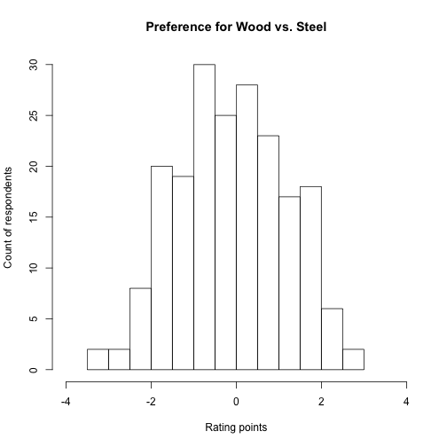

```r
hist(ride.constWood$statistics[ , 1],
     main="Preference for Wood vs. Steel",
     xlab="Rating points", ylab="Count of respondents", xlim=c(-4,4))
```

# Time for Q&A and a break!

### Notes

This presentation is based on Chapter 9 of Chapman and Feit, *R for Marketing Research and Analytics* © 2015 Springer.

All code in the presentation is licensed under the Apache License, Version 2.0 (the “License”); you may not use this file except in compliance with the License. You may obtain a copy of the License at [http://www.apache.org/licenses/LICENSE-2.0\](http://www.apache.org/licenses/LICENSE-2.0%5C) Unless required by applicable law or agreed to in writing, software distributed under the License is distributed on an “AS IS” BASIS, WITHOUT WARRANTIES OR CONDITIONS OF ANY KIND, either express or implied. See the License for the specific language governing permissions and limitations under the License.